# IC-Case 31- Summary of Data Analysis for R3, R6, and R4

# R4b: Residence and awareness of services

## Cross-tabulation

```r
aware_items <- paste0("q", 13:26)

xtab_one <- function(v) {
  g <- data$residence
  x <- factor(as.numeric(data[[v]]), levels = 1:3,
              labels = c("Used", "Aware, not used", "Unaware"))
  tab <- table(g, x)
  pct <- round(prop.table(tab, 1) * 100, 1)
  chi <- suppressWarnings(chisq.test(tab, correct = FALSE))
  # If any expected count is below 5, also get a simulated p-value as a check
  mc <- if (min(chi$expected) < 5) {
    set.seed(6500)
    format.pval(chisq.test(tab, simulate.p.value = TRUE, B = 10000)$p.value, digits = 3, eps = 0.001)
  } else "-"
  V <- sqrt(unname(chi$statistic) / (sum(tab) * (min(dim(tab[, colSums(tab) > 0])) - 1)))
  tibble(
    Service = sub("^Q[0-9]+-Aware_", "", attr(data[[v]], "label")),
    `HQ Used` = pct["HQ area", "Used"], `HQ Aware` = pct["HQ area", "Aware, not used"],
    `HQ Unaware` = pct["HQ area", "Unaware"],
    `Else Used` = pct["Elsewhere", "Used"], `Else Aware` = pct["Elsewhere", "Aware, not used"],
    `Else Unaware` = pct["Elsewhere", "Unaware"],
    `Chi-sq` = round(unname(chi$statistic), 2), df = unname(chi$parameter),
    p = format.pval(chi$p.value, digits = 3, eps = 0.001),
    `Cramer's V` = round(V, 2),
    `Min expected` = round(min(chi$expected), 1),
    `Simulated p` = mc
  )
}

r4b <- bind_rows(lapply(aware_items, xtab_one))
kable(r4b)
```

Table 7: R4b: Awareness of services by residence (row percentages) and chi-square independence tests

| Service | HQ Used | HQ Aware | HQ Unaware | Else Used | Else Aware | Else Unaware | Chi-sq | df | p | Cramer’s V | Min expected | Simulated p |
| --- | --- | --- | --- | --- | --- | --- | --- | --- | --- | --- | --- | --- |
| regular share account | 12.3 | 28.1 | 59.6 | 8.5 | 22.5 | 69.0 | 1.27 | 2 | 0.529 | 0.10 | 5.8 | - |
| special subaccounts | 7.0 | 54.4 | 38.6 | 11.3 | 54.9 | 33.8 | 0.81 | 2 | 0.666 | 0.08 | 5.3 | - |
| Christmas club account | 8.8 | 61.4 | 29.8 | 8.5 | 56.3 | 35.2 | 0.42 | 2 | 0.81 | 0.06 | 4.9 | 0.854 |
| Individual Retirement Account | 24.6 | 47.4 | 28.1 | 21.1 | 52.1 | 26.8 | 0.33 | 2 | 0.849 | 0.05 | 12.9 | - |
| MasterCard credit card | 43.9 | 38.6 | 17.5 | 43.7 | 49.3 | 7.0 | 3.79 | 2 | 0.15 | 0.17 | 6.7 | - |
| signature loans | 14.0 | 78.9 | 7.0 | 15.5 | 83.1 | 1.4 | 2.66 | 2 | 0.265 | 0.14 | 2.2 | 0.32 |
| new car loans | 17.5 | 78.9 | 3.5 | 19.7 | 76.1 | 4.2 | 0.16 | 2 | 0.925 | 0.03 | 2.2 | 0.936 |
| late model car loans | 10.5 | 75.4 | 14.0 | 11.3 | 83.1 | 5.6 | 2.63 | 2 | 0.269 | 0.14 | 5.3 | - |
| older model car loans | 7.0 | 66.7 | 26.3 | 11.3 | 63.4 | 25.4 | 0.67 | 2 | 0.714 | 0.07 | 5.3 | - |
| household goods/appliance loans | 8.8 | 57.9 | 33.3 | 8.5 | 66.2 | 25.4 | 1.05 | 2 | 0.592 | 0.09 | 4.9 | 0.622 |
| recreational loans | 8.8 | 52.6 | 38.6 | 11.3 | 42.3 | 46.5 | 1.38 | 2 | 0.502 | 0.10 | 5.8 | - |
| share collateralized loans | 1.8 | 43.9 | 54.4 | 1.4 | 45.1 | 53.5 | 0.04 | 2 | 0.981 | 0.02 | 0.9 | 1 |
| IRA loans | 0.0 | 36.8 | 63.2 | 5.6 | 35.2 | 59.2 | 3.32 | 2 | 0.19 | 0.16 | 1.8 | 0.214 |
| line of credit loans | 35.1 | 64.9 | 0.0 | 39.4 | 60.6 | 0.0 | NaN | 2 | NA | NaN | 0.0 | NA |

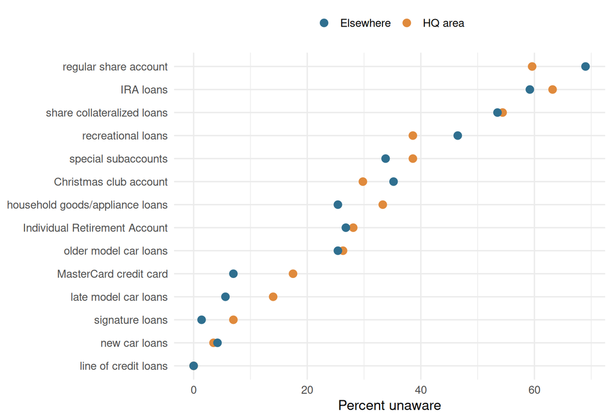

Figure 3: R4b: Percent of members who are unaware of each service, by residence

```r
r4b |>
  select(Service, `HQ area` = `HQ Unaware`, Elsewhere = `Else Unaware`) |>
  pivot_longer(-Service, names_to = "Residence", values_to = "pct") |>
  mutate(Service = reorder(Service, pct)) |>
  ggplot(aes(x = pct, y = Service, color = Residence)) +
  geom_point(size = 3) +
  scale_color_manual(values = c("#2f6f8f", "#e08a3c")) +
  labs(x = "Percent unaware", y = NULL, color = NULL) +
  theme(legend.position = "top")
```

## What It Means

- Awareness is about the same no matter where a member lives. None of the 14 services shows a significant difference between the HQ area and elsewhere (all p > .10, Table 7), and the effect sizes (Cramer’s V) are small.
- The biggest gap is for the MasterCard, where 17.5% of HQ members are unaware compared with 7.0% of members elsewhere (p = .150). That is not strong enough to call a real difference.
- For the few services with small expected counts, the simulated p-values lead to the same conclusion, so the chi-square results are not driven by that issue.
- The awareness problem from R5 (low awareness of IRA loans, share collateralized loans, and recreational loans) is a credit-union-wide problem, not a location problem (Figure 3). The two groups follow nearly the same pattern, so the same awareness campaign can go to everyone.